# Sensivity analyses

### 1. Analysis presented in the briefing

The figures below shows seven-day moving averages of daily admissions and discharges in 2020, indexed relative to the average for the same period across 2015-2019.

Please note that hospital admissions usually decrease in the time period around the Easter weekend.

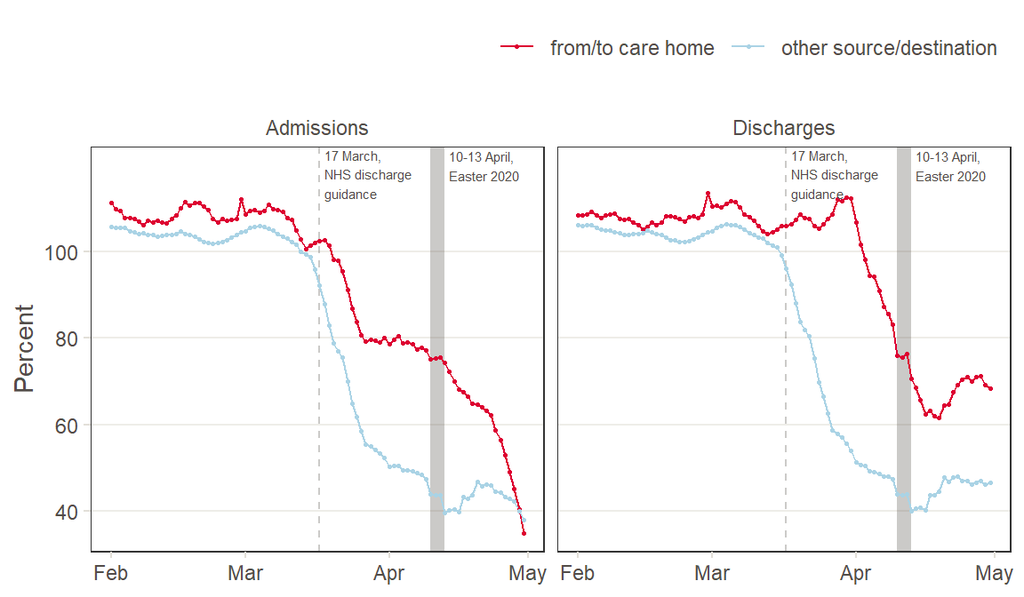

### 2. Sensitivity analysis: excluding long hospital spells

Our original analysis may underestimate the number of hospital admissions towards the end of April. This is because data for patients who are still in the hospital by the end of the reporting period might not be included.

This analysis of hospital admissions from care homes and hospital discharges to care homes includes only hospital spells with a **length of stay of less than 45 days**. The rationale for this analysis is to test whether excluding spells for patients who were still in hospital at the end of the reporting period has an effect on the pattern of admissions and discharges.

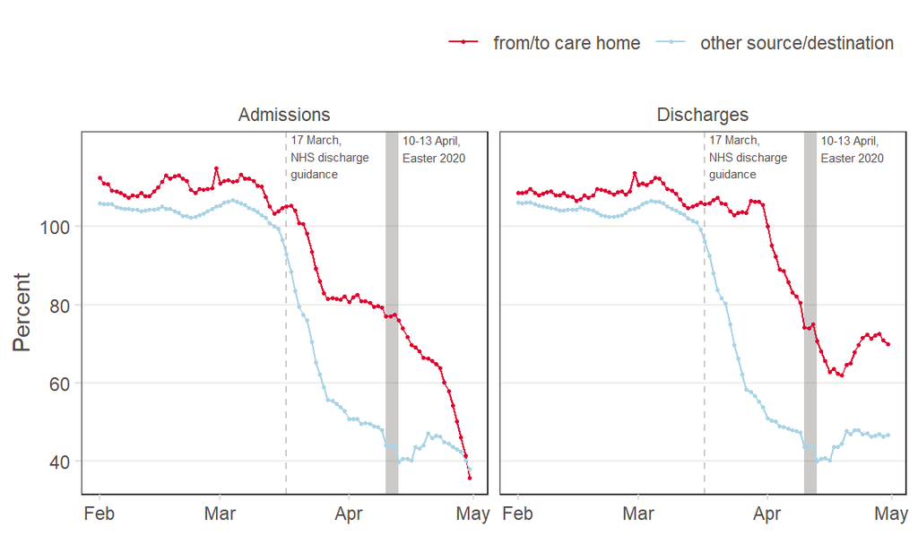

### 3. Sensitivity analysis: excluding spells for care home residents without an address match

Our original analysis uses a broad definition of care home admissions and discharges. It is based on GP-registered patient addresses, which are matched to care home addresses, as well as information recorded in hospital records.

This analysis of hospital admissions from care homes and hospital discharges to care homes is exclusively based on residents with a GP-registered addresses that matches a care home. This definition was also used in previous IAU publications. The rationale for this analysis is to test whether not taking into account admissions and discharge information in hospital records has an effect on the pattern of admissions and discharges.

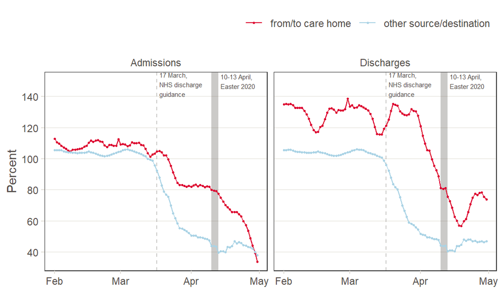

Note: The number of discharges of to care homes identified via address matching is higher at the start of 2020 compared to previous years. Whether changes in the address matching process might have contributed to this is currently being investigated.